# Untitled

```r
Sys.getenv("RSTUDIO_PANDOC")
```

```
## [1] "/Users/willpowell/opt/anaconda3/bin/pandoc"
```

2.)

```r
setwd("~/Desktop")
data <- read.csv(file = "bea-2006 (1).csv", header = TRUE)

x <- log(data[[3]])
y <- data[[2]]

model <- lm(formula = y ~ x, data=data)
summary(model)
```

```
##
## Call:
## lm(formula = y ~ x, data = data)
##
## Residuals:
##    Min     1Q Median     3Q    Max
## -21572  -4765  -1016   3686  40207
##
## Coefficients:
##             Estimate Std. Error t value Pr(>|t|)
## (Intercept) -23306.2     4957.1  -4.702 3.67e-06 ***
## x             4449.8      390.9  11.383  < 2e-16 ***
## ---
## Signif. codes:  0 '***' 0.001 '**' 0.01 '*' 0.05 '.' 0.1 ' ' 1
##
## Residual standard error: 7929 on 364 degrees of freedom
## Multiple R-squared:  0.2625, Adjusted R-squared:  0.2605
## F-statistic: 129.6 on 1 and 364 DF,  p-value: < 2.2e-16
```

```r
model_summ <- summary(model)
mse <- mean(model_summ$residuals^2)
mse
```

```
## [1] 62519376
```

```r
condvar <- mean(residuals)^2
condvar
```

```
## [1] NA
```

2c.) Pittsburgh has a population of 2361000, and a per capita GMP of 38350. For model prediction see below:

```r
y <- log(2361000)*4449.8 - 23306.2
y
```

```
## [1] 41992.82
```

```r
residual <- 38350 - y

residual
```

```
## [1] -3642.816
```

Predicted value is 41992.82, and the residual is -3642.816

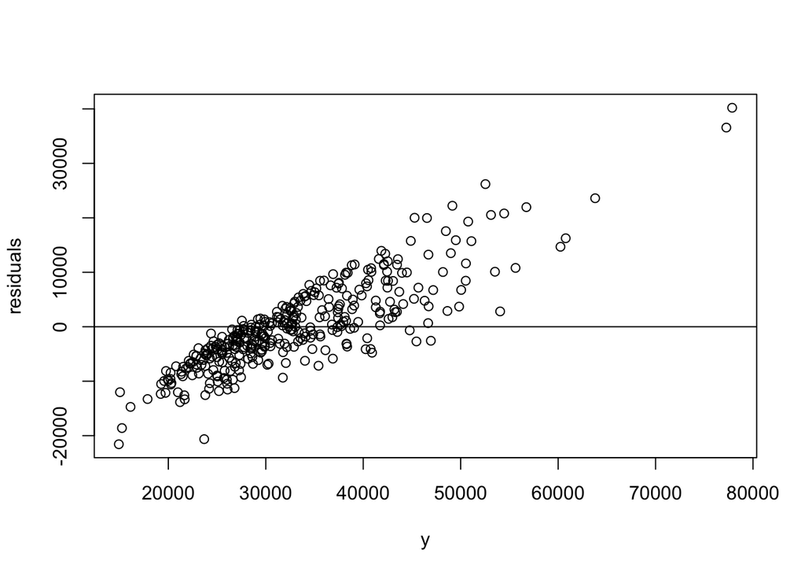

```r
setwd("~/Desktop")
data <- read.csv(file = "bea-2006 (1).csv", header = TRUE)

x <- log(data[[3]])
y <- data[[2]]

model <- lm(formula = y ~ x, data=data)

residuals <- resid(model)

plot(y, residuals)
abline(0,0)
```

If the assumptions of a simple linear model were to hold, there should be no pattern to the residual plot. Here there appears to be a linear pattern to the residual plot, suggesting that a linear model does not hold.

2e.) Estimated Slope

```r
slope <- 4449.8
error <- 390.9
l <- slope - 1.645*error
h <- slope + 1.645*error
l
```

```
## [1] 3806.77
```

```r
h
```

```
## [1] 5092.831
```

Estimated slope interpretation: For 2 values whose log populations happen to differ by 1, the expected difference in GMP is 4449.8.

3.)

```r
setwd("~/Desktop")
data <- read.table(file = "bp.txt", header = TRUE)

data
```

| weight | sysbp |
| --- | --- |
| 165 | 130 |
| 167 | 133 |
| 180 | 150 |
| 155 | 128 |
| 212 | 151 |
| 175 | 146 |
| 190 | 150 |
| 210 | 140 |
| 200 | 148 |
| 149 | 125 |

[output cut: 16 more lines]

```r
plot(x = data[[1]], y = data[[2]])
model <- lm(formula = data[[2]] ~ data[[1]], data = data)
summary(model)
```

```
##
## Call:
## lm(formula = data[[2]] ~ data[[1]], data = data)
##
## Residuals:
##     Min      1Q  Median      3Q     Max
## -17.182  -6.485  -2.519   8.926  12.143
##
## Coefficients:
##             Estimate Std. Error t value Pr(>|t|)
## (Intercept) 69.10437   12.91013   5.353 1.71e-05 ***
## data[[1]]    0.41942    0.07015   5.979 3.59e-06 ***
## ---
## Signif. codes:  0 '***' 0.001 '**' 0.01 '*' 0.05 '.' 0.1 ' ' 1
##
## Residual standard error: 8.681 on 24 degrees of freedom
## Multiple R-squared:  0.5983, Adjusted R-squared:  0.5815
## F-statistic: 35.74 on 1 and 24 DF,  p-value: 3.591e-06
```

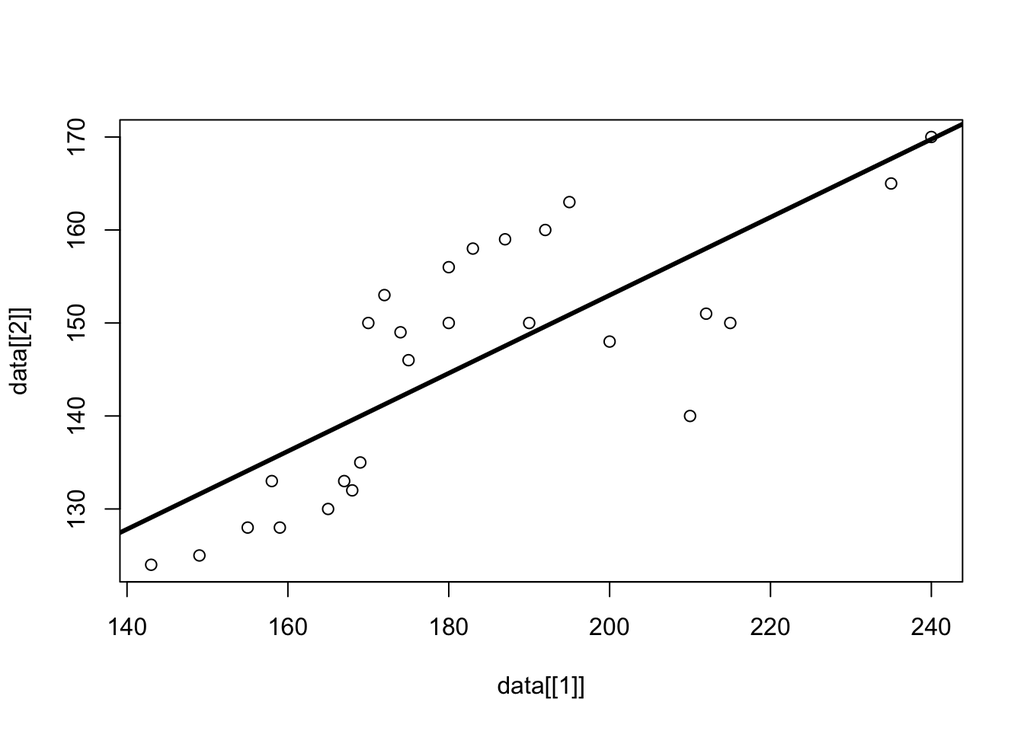

```r
abline(model, color="blue", lwd=3)
```

Estimate for person who is 200 pounds:

```r
estimate <- 200*.41942 + 69.10437
estimate
```

```
## [1] 152.9884
```

Confidence interval:

```r
l <- 152.9884 - 1.96*sqrt(var(data[[2]]))
l
```

```
## [1] 126.6859
```

```r
h <- 152.9884 + 1.96*sqrt(var(data[[2]]))
h
```

```
## [1] 179.2909
```

The 95% C.I is 126.6859, 179.2909

3b.) New person 145 pounds. The estimated blood pressure and C.I:

```r
guess <- 145*.41942 + 69.10437
guess
```

```
## [1] 129.9203
```

```r
l <- guess - 1.96*sqrt(var(data[[2]]))
l
```

```
## [1] 103.6178
```

```r
h <- guess + 1.96*sqrt(var(data[[2]]))
h
```

```
## [1] 156.2227
```

Estimate: 129.9203 C.I.: 103.6178, 156.2227